# Homework 2

Fatma Zehra Cetin - IE582 - Fall 2018

**1. EXPLANATIONS AND COMMENTS OF PERFORMING TASKS**

**Task 1:**

**Task 1 a):**

**A. Explanation**

First of all I need to tell that: due to problem of knitting to HTML Error (pandoc document conversion failed with error 99), I need to translate this form and run them seperately and adding their picture as a figure. I am really sorry about that. I should try it very early and handle it.

In order to understand, if over/under 2.5 game result can be explained by the odds for different types of bets, I perform an analysis in an unsupervised way. For each game, I ended up with a feature vector of the odds. There is a mistake that I made performing tasks, I just used 2.5 totalhandicap. But unfortunately, later I notice the diffferent totalhandicaps represent different types of bets. Due to I don’t have enough time I couldn’t implement this. After creating this feature vector (which is wrong actually which has missing values), I scaled date before perform the PCA. After scaling, I perform the PCA. To perform this task 1, I repeat this steps for each bookmaker respectively: Pinnacle, Unibet, 10Bet, Tipico and Betsson. Due to problem I can just give two of them which are Pinnacle and Unibet.For being able to interpret beyond PCA results(eigenvectors, variance covered) also plot the new coordinates which represent(PC1, PC2 and/or PC3) where the points are color-coded based on their under/over 2.5 status. Due to I couldn’t coded different colors I used light blue and daark blue. Due to OverUnder values binary, there is only light and dark blue points.

**B. Comments of PCA Results**

1. Pinnacle: When I look the points I couldn’t see any cluster or difference between light and dark points. It means PCA couldn’t explain over/under 2.5 game results.
2. Unibet: When I apply PCA for bookmaker Unibet it gave me only one principal component.That’s why I couldn’t plot this data. Probably, I created a wrong feature vector. Because for Pinnacle also PCA and MDS didn’t explain.

**Task 1 b):**

**A. Explanation**

In order to perform this task, I transform data matrix to distance matrix. After this step, I scaled the data. Then, I performed MDS using Manhattan and Euclidean distance.

**B.Comments of MDS Results**

1. Pinnacle: When I look these graphs, we can see over and under scores together which means MDS on Euclidean distance and Manhattan distance couldn’t explain.

**Task 1 c):**

**A. Explanation**

In order to see which dimensionality reduction method (MDS and PCA) works better with bookmaker Pinnacle’s odds for this problem, I compare the PCA results with MDS . Over/under 2.5 game result can be explained by the Pinnacle’s odds for different types of bets.

**B.Comments of Comparision of PCA Results with MDS**

When I compare PCA results with MDS results, I can conclude that: neither PCA nor MDs could explain it.

**Task 2:**

**Task 2 a):**

**A. Explanation**

**B. Comments of PCA Results**

1. Pinnacle: When I look the graph, I could see the all data looks mix. There are no cluster for home away or tie match outcomes. It means PCA couldn’t explain home away tie match outcomes.

**Task 2 b):**

**A. Explanation**

In order to perform this task, I transform data matrix to distance matrix. After this step, I scaled the data. Then, I performed MDS using Manhattan and Euclidean distance.

**B.Comments of MDS Results**

1. Pinnacle: When I look the MDS graphs, for both MDS graphs home away and draw odds looks seperately and almost same positions.

**Task 2 c):**

**Task 3:**

**A. Explanation**

In order to perform this task, I install a husky dog pigture and save as .jpeg file. I resize the image to size to 200x200 px to perform fast task.

**Task 3 1):**

**A. Explanation**

As in appendix part, I read image as a variable in R. But due to knitting problem, I couldn’t share outputs and codes in chunk.

**Task 3 2):**

**A. Explanation**

Structure of the variable that stores the image is numerical and matrix. It has 3 dimensions.

**Task 3 3):**

**A. Explanation**

In order to create a noisy image, I add a random noise from uniform distribution between 0 and 0.1 to each pixel value for each channel of original image. But it didn’t give the noisy image. I guees I should have thought different for dimension but I couldn’t handle it. That’s why I couldn’t go beyond that part.For b part also I gave the codes but it didn’t work due to wrong noisy image.

**2. FIGURES**

**2.1. Task 1 a):**

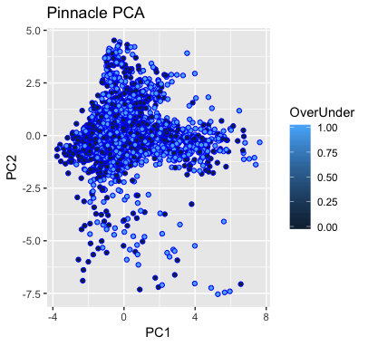

Pinnacle PCA

**2.2. Task 1 b):**

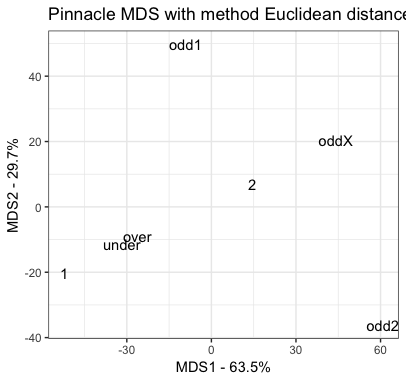

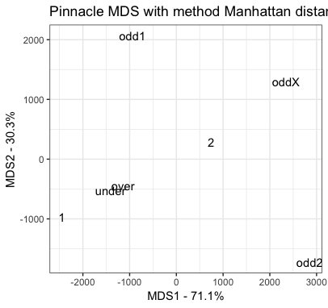

**2.3. Task 2 a) :**

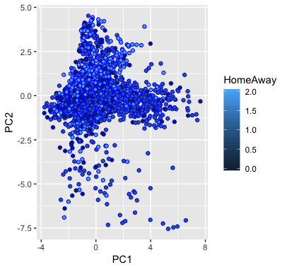

Pinnacle PCA

**2.4. Task 2 b) :**

[figure not shown]

Pinnacle MDS on Euclidean Distance

[figure not shown]

Pinnacle MDS on Manhattan Distance

**2.5. Task 3. 2 :**

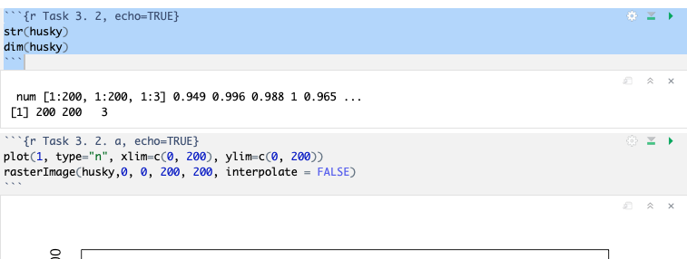

**2.6. Task 3. 2 a):**

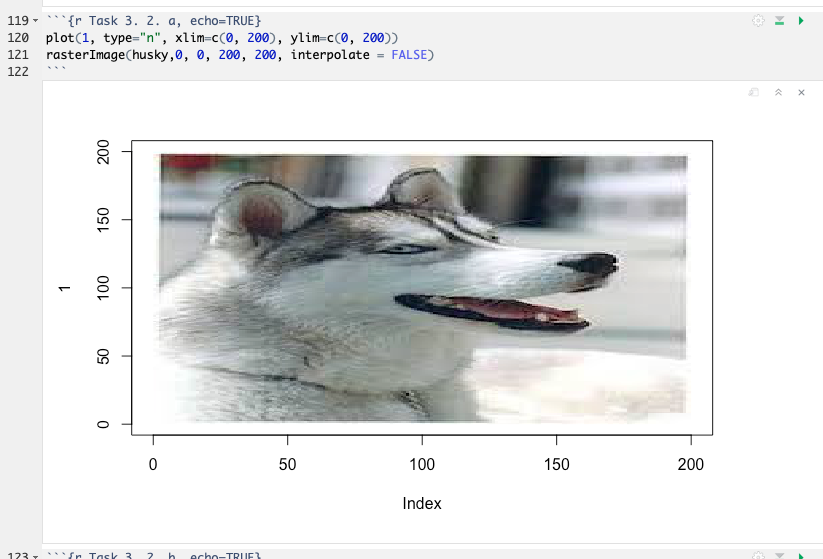

**2.7. Task 3. 2 b):**

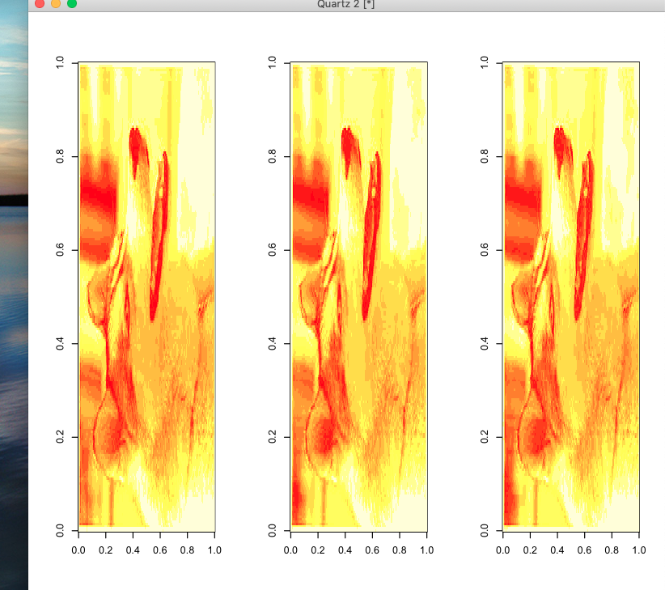

**2.8. Task 3. 3 a):**

[figure not shown]

**3. APPENDIX**

** Appendix: R codes **

**3.1. Task 1 a :**

**3.1.1. Code for Bookmaker: Pinnacle:**

require(data.table)

require(anytime)

require(ggplot2)

matches=readRDS(“~/Desktop/IE 582/IE582Fall2018_project_files/df9b1196-e3cf-4cc7-9159-f236fe738215_matches.rds”)

odds=readRDS(“~/Desktop/IE 582/IE582Fall2018_project_files/df9b1196-e3cf-4cc7-9159-f236fe738215_odd_details.rds”)

matches=unique(matches)

matches[ ,match_date := anydate(date)]

matches[ ,match_time := anytime(date)]

matches[,c(“HomeGoals”,“AwayGoals”):=tstrsplit(score,‘:’)]

matches=matches[complete.cases(matches)]

matches[,HomeGoals:=as.numeric(HomeGoals)]

matches[,AwayGoals:=as.numeric(AwayGoals)]

matches[,TotalGoals:=HomeGoals+AwayGoals]

matches[,OverUnder:=0]

matches[TotalGoals>2.5,OverUnder:=1]

odds=unique(odds)

odds[ ,match_date := anydate(date)]

odds_ov_un=odds[betType==‘ou’ & totalhandicap==‘2.5’]

odds_ov_un[,totalhandicap:=NULL]

odds_ov_un=odds_ov_un[order(matchId, oddtype,bookmaker,date)]

odds_ov_un_final=odds_ov_un[,list(final_odd=odd[.N]),by=list(matchId,oddtype,bookmaker)]

wide_odds_final=dcast(odds_ov_un_final,matchId~oddtype+bookmaker,value.var=‘final_odd’)

pinnacle_over_under_final=odds_ov_un_final[bookmaker==‘Pinnacle’]

pinnacle_wide_final=dcast(pinnacle_over_under_final,matchId~oddtype,value.var=‘final_odd’)

odds_oddtype=odds[order(matchId, oddtype,bookmaker,date)]

odds_oddtype_final=odds[,list(final_odd=odd[.N]),by=list(matchId,oddtype,bookmaker)]

pinnacle_oddtype=odds_oddtype_final[bookmaker==‘Pinnacle’]

pinnacle_wide_oddtype=dcast(pinnacle_oddtype,matchId~oddtype,value.var=‘final_odd’)

pinnacle_wide_oddtype[,over:=NULL]

pinnacle_wide_oddtype[,under:=NULL]

merged_odds_pinnacle=merge(pinnacle_wide_final,pinnacle_wide_oddtype,by=‘matchId’)

merged_odds_final_newcategory_pinnacle<-merge(merged_odds_pinnacle,matches,by=‘matchId’)

merged_odds_final_newcategory_pinnacle<-merged_odds_final_newcategory_pinnacle[,-9:-19]

merged_odds_final_newcategory_pinnacle_withoutmatchid<-merged_odds_final_newcategory_pinnacle[,-1]

merged_odds_final_newcategory_pinnacle_withoutmatchid_forpca<-merged_odds_final_newcategory_pinnacle_wit houtmatchid[,-8]

PCA_pinnacle<-prcomp(merged_odds_final_newcategory_pinnacle_withoutmatchid_forpca_scaled)

summary(PCA_pinnacle)

str(PCA_pinnacle)

PCA_pinnacle$x

merged_odds_pinnacle_combined<-cbind(merged_odds_final_newcategory_pinnacle_withoutmatchid,PCA_pinnacle$x[,1:2])

ggplot(merged_odds_pinnacle_combined,aes(PC1,PC2,col=OverUnder,fill=OverUnder))+geom_point(shape=21,col=“blue”) + gtitle(“Pinnacle PCA”)

cor(merged_odds_final_newcategory_pinnacle_withoutmatchid,merged_odds_pinnacle_combined[,9:10])

**3.1. Task 1 b :**

dist_pinnacle<-dist(scale(t(merged_odds_final_newcategory_pinnacle_withoutmatchid[,-8]), center=TRUE, scale=TRUE),method = “euclidean”)

mds_pinnacle<-cmdscale(dist_pinnacle,eig = TRUE,x.ret = TRUE)

mds.var<-round(mds_pinnacle$eig/sum(mds_pinnacle$eig)*100,1)

mds.values.pinnacle<-mds_pinnacle$points

mds.data.pinnacle<-data.frame(sample=rownames(mds.values.pinnacle), X=mds.values.pinnacle[,1], Y=mds.values.pinnacle[,2])

ggplot(data=mds.data.pinnacle, aes(x=X, y=Y, label=sample)) + geom_text() + theme_bw() + xlab(paste(“MDS1 -”, mds.var[1], “%”, sep="“)) + ylab(paste(”MDS2 - “, mds.var[2],”%“, sep=”“)) + ggtitle(”Pinnacle MDS with method Euclidean distance")

dist_pinnacle_manhattan<-dist(scale(t(merged_odds_final_newcategory_pinnacle_withoutmatchid[,-8]), center=TRUE, scale=TRUE),method = “manhattan”)

mds_pinnacle_manhattan<-cmdscale(dist_pinnacle_manhattan,eig = TRUE,x.ret = TRUE)

mds.var<-round(mds_pinnacle_manhattan$eig/sum(mds_pinnacle_manhattan$eig)*100,1)

mds.values.pinnacle_manhattan<-mds_pinnacle_manhattan$points

mds.data.pinnacle_manhattan<-data.frame(sample=rownames(mds.values.pinnacle_manhattan), X=mds.values.pinnacle_manhattan[,1], Y=mds.values.pinnacle_manhattan[,2])

ggplot(data=mds.data.pinnacle_manhattan, aes(x=X, y=Y, label=sample)) + geom_text() + theme_bw() + xlab(paste(“MDS1 -”, mds.var[1], “%”, sep="“)) + ylab(paste(”MDS2 - “, mds.var[2],”%“, sep=”“)) + ggtitle(”Pinnacle MDS with method Manhattan distance")

**3.2. Task 2 a :**

**3.2.1. Code for Bookmaker: Pinnacle:**

require(data.table)

require(anytime)

require(ggplot2)

matches=readRDS(“~/Desktop/IE 582/IE582Fall2018_project_files/df9b1196-e3cf-4cc7-9159-f236fe738215_matches.rds”)

odds=readRDS(“~/Desktop/IE 582/IE582Fall2018_project_files/df9b1196-e3cf-4cc7-9159-f236fe738215_odd_details.rds”)

matches=unique(matches)

matches[ ,match_date := anydate(date)]

matches[ ,match_time := anytime(date)]

matches[,c(“HomeGoals”,“AwayGoals”):=tstrsplit(score,‘:’)]

matches=matches[complete.cases(matches)]

matches[,HomeGoals:=as.numeric(HomeGoals)]

matches[,AwayGoals:=as.numeric(AwayGoals)]

matches[,TotalGoals:=HomeGoals+AwayGoals]

matches[,HomeAway:=0]

matches[HomeGoals>AwayGoals,HomeAway:=1]

matches[HomeGoals<AwayGoals,HomeAway:=2]

odds=unique(odds)

odds[ ,match_date := anydate(date)]

odds_1x2=odds[betType==‘1X2’]

odds_1x2[,totalhandicap:=NULL]

odds_1x2=odds_1x2[order(matchId, oddtype,bookmaker,date)]

odds_1x2_final=odds_1x2[,list(final_odd=odd[.N]),by=list(matchId,oddtype,bookmaker)]

wide_odds_final=dcast(odds_ov_un_final,matchId~oddtype+bookmaker,value.var=‘final_odd’)

pinnacle_1x2_final=odds_1x2_final[bookmaker==‘Pinnacle’]

pinnacle_wide_final=dcast(pinnacle_1x2_final,matchId~oddtype,value.var=‘final_odd’)

odds_oddtype=odds[order(matchId, oddtype,bookmaker,date)]

odds_oddtype_final=odds[,list(final_odd=odd[.N]),by=list(matchId,oddtype,bookmaker)]

pinnacle_oddtype=odds_oddtype_final[bookmaker==‘Pinnacle’]

pinnacle_wide_oddtype=dcast(pinnacle_oddtype,matchId~oddtype,value.var=‘final_odd’)

pinnacle_wide_oddtype[,over:=NULL]

pinnacle_wide_oddtype[,under:=NULL]

merged_odds_pinnacle=merge(pinnacle_wide_final,pinnacle_wide_oddtype,by=‘matchId’)

merged_odds_final_newcategory_pinnacle<-merge(merged_odds_pinnacle,matches,by=‘matchId’)

merged_odds_final_newcategory_pinnacle<-merged_odds_final_newcategory_pinnacle[,-9:-19]

merged_odds_final_newcategory_pinnacle_withoutmatchid<-merged_odds_final_newcategory_pinnacle[,-1]

merged_odds_final_newcategory_pinnacle_withoutmatchid_forpca<-merged_odds_final_newcategory_pinnacle_wit houtmatchid[,-8]

merged_odds_final_newcategory_pinnacle_withoutmatchid_forpca_scaled=scale(merged_odds_final_newcategory_ pinnacle_withoutmatchid_forpca, center = TRUE, scale = TRUE)

PCA_pinnacle<-prcomp(merged_odds_final_newcategory_pinnacle_withoutmatchid_forpca_scaled)

summary(PCA_pinnacle)

str(PCA_pinnacle)

PCA_pinnacle$x

merged_odds_pinnacle_combined<-cbind(merged_odds_final_newcategory_pinnacle_withoutmatchid,PCA_pinnacle$x[,1:2])

ggplot(merged_odds_pinnacle_combined,aes(PC1,PC2,col=HomeAwat,fill=HomeAway))+geom_point(shape=21,col=“blue”)

cor(merged_odds_final_newcategory_pinnacle_withoutmatchid,merged_odds_pinnacle_combined[,9:10])

**3.2. Task 2 b :**

dist_pinnacle<-dist(scale(t(merged_odds_final_newcategory_pinnacle_withoutmatchid[,-8]), center=TRUE, scale=TRUE),method = “euclidean”)

mds_pinnacle<-cmdscale(dist_pinnacle,eig = TRUE,x.ret = TRUE)

mds.var<-round(mds_pinnacle$eig/sum(mds_pinnacle$eig)*100,1)

mds.values.pinnacle<-mds_pinnacle$points

mds.data.pinnacle<-data.frame(sample=rownames(mds.values.pinnacle), X=mds.values.pinnacle[,1], Y=mds.values.pinnacle[,2])

ggplot(data=mds.data.pinnacle, aes(x=X, y=Y, label=sample)) + geom_text() + theme_bw() + xlab(paste(“MDS1 -”, mds.var[1], “%”, sep="“)) + ylab(paste(”MDS2 - “, mds.var[2],”%“, sep=”“)) + ggtitle(”Pinnacle MDS with method Euclidean distance")

dist_pinnacle_manhattan<-dist(scale(t(merged_odds_final_newcategory_pinnacle_withoutmatchid[,-8]), center=TRUE, scale=TRUE),method = “manhattan”)

mds_pinnacle_manhattan<-cmdscale(dist_pinnacle_manhattan,eig = TRUE,x.ret = TRUE)

mds.var<-round(mds_pinnacle_manhattan$eig/sum(mds_pinnacle_manhattan$eig)*100,1)

mds.values.pinnacle_manhattan<-mds_pinnacle_manhattan$points

mds.data.pinnacle_manhattan<-data.frame(sample=rownames(mds.values.pinnacle_manhattan), X=mds.values.pinnacle_manhattan[,1], Y=mds.values.pinnacle_manhattan[,2])

ggplot(data=mds.data.pinnacle_manhattan, aes(x=X, y=Y, label=sample)) + geom_text() + theme_bw() + xlab(paste(“MDS1 -”, mds.var[1], “%”, sep="“)) + ylab(paste(”MDS2 - “, mds.var[2],”%“, sep=”“)) + ggtitle(”Pinnacle MDS with method Manhattan distance")

**3.3. Task 3 :**

**3.3.1. Code**

require(jpeg)

readJPEG(“/Users/zehra/Desktop/husky.jpg”)

husky=readJPEG(“/Users/zehra/Desktop/husky.jpg”)

**3.3.2. Code**

str(husky)

dim(husky)

**3.3.2.a. Code**

plot(1, type=“n”, xlim=c(0, 200), ylim=c(0, 200))

rasterImage(husky,0, 0, 200, 200, interpolate = FALSE)

**3.3.2.b. Code**

par(mfrow=c(1,3))

image(husky[,,1])

image(husky[,,2])

image(husky[,,3])

**3.3.3.a. Code**

set.seed(12)

noise_channelR=matrix(runif(40000,0,0.1),200,200,1)

noise_channelG=matrix(runif(40000,0,0.1),200,200,2)

noise_channelB=matrix(runif(40000,0,0.1),200,200,3)

husky=as.matrix(husky)

noisy_husky=noise_channelR + noise_channelG + noise_channelB + image(husky)

plot(1, type=“n”, xlim=c(0, 200), ylim=c(0, 200))

rasterImage(noisy_husky,0, 0, 200, 200, interpolate = FALSE)

**3.3.3.b. Code**

par(mfrow=c(1,3))

image(noisy_husky[,,1])

image(noisy_husky[,,2])

image(noisy_husky[,,3])

**3.3.4.a. Code**

**3.3.4.b. Code**

**3.3.4.c. Code**